# Demo 4 | Impacted Inferences

Peter Kedron

2026-09-22

# 1. Introduction

Many familiar statistical procedures begin with an assumption that is easy to overlook: **observations are independent of one another**. Under independence, each additional observation contributes a new piece of information about the process we are trying to estimate. This is what allows familiar quantities such as the standard error of a mean to decrease as sample size increases.

Geographic observations complicate this assumption. Tobler’s First Law tells us that nearby things tend to be more related than distant things. Two observations collected close together may therefore contain partly redundant information rather than two completely independent pieces of evidence.

This demonstration asks what happens to statistical inference when we ignore that redundancy. We will move through the problem in four stages:

1. begin with three simple observations and examine what dependence does to the mean and its uncertainty;
2. simulate increasing spatial dependence on a lattice and measure how much information is lost;
3. examine what that information loss does to a conventional hypothesis test; and
4. apply the same reasoning to a classic agricultural field experiment.

# 2. A Geographer’s Intuition

Consider three observations collected at the locations shown below. Each varies around a common unknown mean $\mu$, and each has the same individual variance:

$$x_1 = 0.9889, \qquad x_2 = 1.388, \qquad x_3 = -0.6242$$

$$x_i \sim N(\mu,\sigma_i^2), \qquad \sigma_i^2 = 1$$

If we knew nothing about where these observations came from, we might simply treat all three as independent.

But their locations give us additional information. Locations 1 and 2 are close together, while location 3 is much farther away. If Tobler’s First Law applies, the first two observations may therefore be more similar to one another than either is to observation 3.

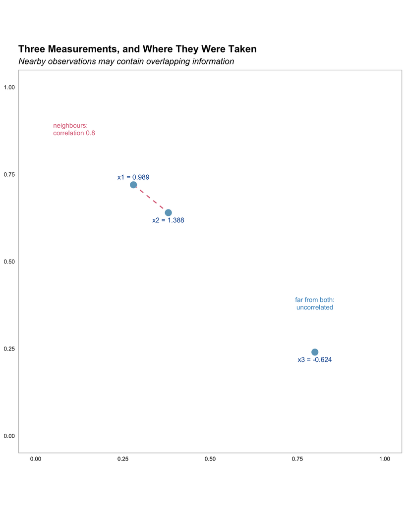

```r
x <- c(0.9889, 1.388, -0.6242)

sites <- tibble(
  id = 1:3,
  east = c(0.28, 0.38, 0.80),
  north = c(0.72, 0.64, 0.24),
  value = x)

d <- as.matrix(dist(sites[, c("east", "north")]))

ggplot(sites, aes(east, north)) +
  geom_line(data = filter(sites, id %in% 1:2),
            colour = cat2[2], linewidth = 0.7, linetype = "dashed") +
  geom_point(size = 4, colour = cat2[1]) +
  geom_text(aes(label = paste0("x", id, " = ", round(value, 3)),
                vjust = ifelse(id == 1, -1.1, 2.0)),
            size = 3.4, colour = continuous_palette[5]) +
  annotate("text", x = 0.05, y = 0.88, hjust = 0, size = 3.3,
           colour = cat2[2], label = "neighbours:\ncorrelation 0.8",
           lineheight = 0.95) +
  annotate("text", x = 0.80, y = 0.38, size = 3.3,
           colour = continuous_palette[4],
           label = "far from both:\nuncorrelated", lineheight = 0.95) +
  scale_x_continuous(limits = c(0, 1), breaks = seq(0, 1, 0.25)) +
  scale_y_continuous(limits = c(0, 1), breaks = seq(0, 1, 0.25)) +
  coord_fixed() +
  labs(
    title = "Three Measurements, and Where They Were Taken",
    subtitle = "Nearby observations may contain overlapping information") +
  themeClean +
  theme(axis.text = element_blank(),
        axis.ticks = element_blank())
```

Figure 1: Three observations in a hypothetical study area. Locations 1 and 2 are treated as strongly correlated, while location 3 is independent of both.

Suppose locations 1 and 2 have a correlation of 0.8, while location 3 is sufficiently distant that it is unrelated to either:

$$\operatorname{Cov}(x_1,x_2)=0.8$$

$$\operatorname{Cov}(x_1,x_3)
=
\operatorname{Cov}(x_2,x_3)
=
0$$

We now have three measurements, but not three independent pieces of information. That distinction affects two questions:

1. **How confident should we be in the estimated mean?**
2. **Should all three observations contribute equally to that mean?**

## 2.1 Confidence in Estimated Mean

For independent observations with common standard deviation $\sigma$, the familiar standard error of the mean is:

$$SE(\bar{x})=\frac{\sigma}{\sqrt{n}}$$

or equivalently,

$$\operatorname{Var}(\bar{x})=\frac{\sigma^2}{n}.$$

This works because the observations do not share information.

When observations covary, however, the variance of the mean must include both the variation of the individual observations and the variation they share:

$$\sigma_{\bar{x}}^{2}
=
\frac{1}{n^{2}}
\sum_{i=1}^{n}\sigma_{i}^{2}
+
\frac{2}{n^{2}}
\sum_{i<j}\operatorname{Cov}(x_{i},x_{j})$$

The first term is the part we already know from conventional statistics. The second term represents **shared variation** created by covariance between pairs of observations. If all observations have variance $\sigma^2$ and none covary, second term disappears and the familiar formula returns:

$$\sigma_{\bar{x}}^2
=
\frac{n\sigma^2}{n^2}
=
\frac{\sigma^2}{n}.$$

For our three observations, the covariance structure is:

```r
# V holds the variances (diagonal) and covariances (off-diagonal).
# Observations 1 and 2 covary at 0.8; observation 3 is independent of both.
V <- matrix(c(1,   0.8, 0,
              0.8, 1,   0,
              0,   0,   1), nrow = 3, byrow = TRUE)

n <- length(x)

tibble(
  term = c("(A) individual variation",
           "(B) shared variation",
           "total variance of the average"),
  value = c(sum(diag(V))/n^2,
            2*sum(V[upper.tri(V)])/n^2,
            sum(V)/n^2)) %>%
  kable() %>%
  kable_styling(full_width = T)
```

term

value

1. individual variation

0.333

2. shared variation

0.178

total variance of the average

0.511

```r
tibble(
  `standard error` = c("assuming independence (term A only)",
                       "accounting for the correlation (A + B)"),
  value = c(1/sqrt(n), sqrt(sum(V)/n^2))) %>%
  kable() %>%
  kable_styling(full_width = T)
```

| standard error | value |
| --- | --- |
| assuming independence (term A only) | 0.577 |
| accounting for the correlation (A + B) | 0.715 |

If we incorrectly assume independence, the standard error is only 0.577. Once the covariance between locations 1 and 2 is included, the standard error becomes **0.715**. Nothing about the sample size or the individual measurement variance changed. The difference comes entirely from the shared variation between neighboring observations.

The intuition is straightforward. Observing location 1 tells us something about location 2. Observing location 2 therefore does not provide an entirely new piece of evidence. If we pretend that it does, we behave as though we have more information than we actually collected. For positively autocorrelated geographic data, this commonly pushes uncertainty in one direction: standard errors become too small and our estimates appear more precise than they really are.

Simply collecting more observations in the same spatially redundant configuration does not necessarily solve the problem. More observations help most when they bring genuinely new information.

## 2.2 Contribution to the Estimated Mean

Dependence affects our confidence in the mean, but it also raises another question: should every observation contribute equally to the estimate? The ordinary sample mean is:

$$\bar{x}
=
\sum_{i=1}^{n}\frac{1}{n}x_i.$$

Every observation receives exactly the same weight. But locations 1 and 2 are partly redundant. Giving both of them full weight effectively allows the same underlying information to influence the estimate twice. One alternative is to weight observations according to how much **new information** they contribute:

$$\tilde{\mu}
=
\frac{\sum_{i=1}^{n}w_i x_i}
{\sum_{i=1}^{n}w_i}.$$

Observations surrounded by strongly correlated neighbors receive less weight, while observations that contribute more independent information receive more. The exact weights depend on the covariance structure among all observations.

```r
w <- colSums(solve(V))

tibble(
  observation = c("1 (neighbour of 2)",
                  "2 (neighbour of 1)",
                  "3 (isolated)"),
  value = x,
  weight = w) %>%
  kable() %>%
  kable_styling(full_width = T)
```

| observation | value | weight |
| --- | --- | --- |
| 1 (neighbour of 2) | 0.989 | 0.556 |
| 2 (neighbour of 1) | 1.388 | 0.556 |
| 3 (isolated) | -0.624 | 1.000 |

Observation 3 carries **1.8 times the weight** of either member of the correlated pair.

That difference matters here because observations 1 and 2 are both positive, while the isolated observation is negative.

```r
tibble(
  estimate = c("simple average", "reweighted average"),
  value = c(mean(x), sum(w * x)/sum(w)),
  `standard error` = c(sqrt(sum(V)/n^2), sqrt(1/sum(w)))) %>%
  kable() %>%
  kable_styling(full_width = T)
```

| estimate | value | standard error |
| --- | --- | --- |
| simple average | 0.584 | 0.715 |
| reweighted average | 0.330 | 0.688 |

The weights also give us another useful quantity. Their sum represents the **effective sample size**:

$$n'=\sum_i w_i.$$

Although we physically collected three observations, their dependence means that they contain only about **2.11 independent observations worth of information**.

# 3. Measuring Information Lost to Spatial Dependence

The three-location example shows the mechanism, but we now want to know how quickly the effect becomes important as spatial dependence increases. One useful summary is the **reduction factor**:

$$\psi=\frac{n'}{n},$$

where:

- $n$ is the number of observations actually collected;
- $n'$ is the effective sample size; and
- $\psi$ describes the fraction of the nominal sample that remains after accounting for dependence.

If $\psi=1$, no information has been lost.

If $\psi=0.5$, a sample of 100 spatial observations contains roughly the same amount of independent information as 50 independent observations.

## 3.1 Simulating Spatial Dependence

To visualize this, consider a $20\times20$ lattice. Each cell is considered a neighbor of the cells sharing one of its edges — rook adjacency. We then simulate values using a spatial autoregressive process. A single parameter, $\rho$, controls the strength of spatial dependence.

At:

- $\rho=0$, neighboring observations do not influence one another;
- as $\rho$ increases, nearby values become progressively more similar.

We will return to the details of spatial autoregressive models later in the course. For now, $\rho$ can simply be interpreted as a control on the strength of spatial dependence.

```r
# Rook's-adjacency weights for an nr x nc grid: cells sharing an edge are
# neighbours. Row-standardised so each row sums to 1.
make_rook_W <- function(nr, nc) {
  coords <- expand.grid(row = seq_len(nr), col = seq_len(nc))
  W <- (as.matrix(dist(coords, method = "manhattan")) == 1) * 1
  diag(W) <- 0
  W / rowSums(W)
}

# Simulate one grid of values with spatial dependence rho
sim_field <- function(rho, W, mu = 0) {
  as.vector(mu + solve(diag(nrow(W)) - rho * W) %*% rnorm(nrow(W)))
}
```

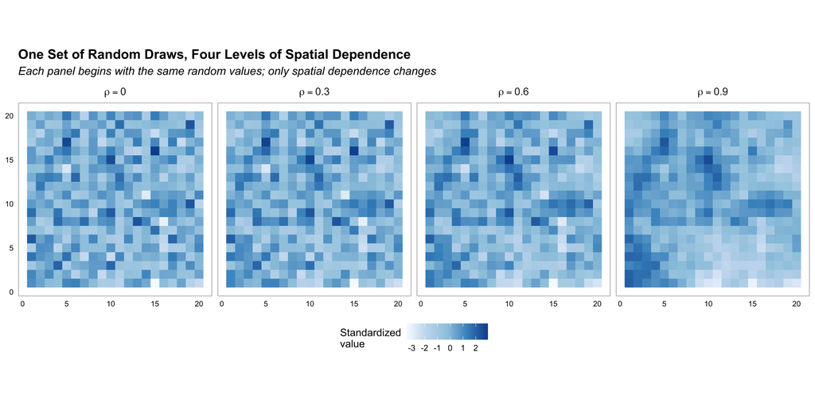

```r
W20 <- make_rook_W(20, 20)

fields <- map_dfr(c(0, 0.3, 0.6, 0.9), function(r) {
  set.seed(2024)
  expand_grid(col = 1:20, row = 1:20) %>%
    arrange(col, row) %>%
    mutate(value = sim_field(r, W20),
           panel = paste0("rho == ", r))
}) %>%
  group_by(panel) %>%
  mutate(z = as.vector(scale(value))) %>%
  ungroup()

ggplot(fields, aes(row, col, fill = z)) +
  geom_raster() +
  facet_wrap(~ panel, nrow = 1, labeller = label_parsed) +
  scale_fill_gradientn(colors = continuous_palette,
                       name = "Standardized\nvalue") +
  coord_fixed() +
  labs(
    title = "One Set of Random Draws, Four Levels of Spatial Dependence",
    subtitle = "Each panel begins with the same random values; only spatial dependence changes") +
  themeClean +
  theme(
    axis.text = element_blank(),
    axis.ticks = element_blank(),
    strip.background = element_blank(),
    strip.text = element_text(size = 11),
    legend.position = "bottom")
```

Figure 2: The same initial random values under four levels of spatial dependence.

At $\rho=0$, the surface resembles random noise. As $\rho$ increases, neighboring cells begin to form larger patches of similar values. The important comparison is between $\rho=0$ and $\rho=0.3$. The difference is visible, but not dramatic. If we were simply inspecting a map, we might not regard $\rho=0.3$ as severe dependence. Statistically, however, its consequences are already substantial.

## 3.2 The Reduction Factor

For the lattice model used here, the reduction factor is represented as:

$$\psi=(1-\rho)^2$$

This connects spatial dependence directly to effective sample size.

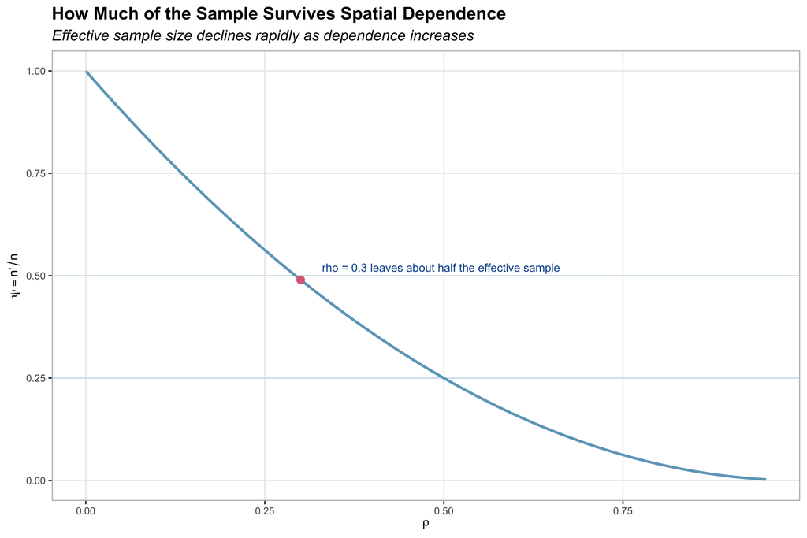

```r
tibble(
  rho = seq(0, 0.95, by = 0.005),
  psi = (1 - rho)^2) %>%
  ggplot(aes(rho, psi)) +
  geom_hline(yintercept = c(0.25, 0.5),
             colour = continuous_palette[2], linewidth = 0.3) +
  geom_line(linewidth = 1, colour = cat2[1]) +
  annotate("point", x = 0.3, y = 0.49,
           colour = cat2[2], size = 2.6) +
  annotate("text", x = 0.33, y = 0.52,
           label = "rho = 0.3 leaves about half the effective sample",
           hjust = 0, size = 3.2, colour = continuous_palette[5]) +
  scale_y_continuous(limits = c(0, 1)) +
  labs(
    title = "How Much of the Sample Survives Spatial Dependence",
    subtitle = "Effective sample size declines rapidly as dependence increases",
    x = expression(rho),
    y = expression(psi == n*minute / n)) +
  themeGrid +
  theme(axis.title = element_text(size = 10))
```

Figure 3: Relationship between spatial dependence and the reduction factor.

At $\rho=0.3$:

$$\psi=(1-0.3)^2=0.49.$$

So 100 nominal observations contain approximately 49 independent observations worth of information. That is the important result: spatial dependence does not need to appear visually extreme before it begins to matter statistically.

```r
tibble(
  rho = c(0, 0.1, 0.2, 0.3, 0.5, 0.6),
  psi = (1 - rho)^2,
  `100 observations are worth` = 100 * psi) %>%
  kable() %>%
  kable_styling(full_width = T)
```

| rho | psi | 100 observations are worth |
| --- | --- | --- |
| 0.0 | 1.00 | 100 |
| 0.1 | 0.81 | 81 |
| 0.2 | 0.64 | 64 |
| 0.3 | 0.49 | 49 |
| 0.5 | 0.25 | 25 |
| 0.6 | 0.16 | 16 |

# 4. Impacted Inferences

So far, spatial dependence has affected the precision of the mean and the effective amount of information in the sample. But what happens when we use that incorrect amount of information to make a statistical decision?

## 4.1 The Impact on a Z-Test

Consider a conventional two-sided hypothesis test:

$$H_0:\mu=0$$

with

$$\alpha=0.05.$$

When the assumptions of the test are satisfied and the null hypothesis is true, we expect to reject it approximately 5% of the time simply because of sampling variation.

Now imagine a spatial world in which the null hypothesis is still true, but observations are spatially dependent.

We simulate a $5\times5$ lattice with:

- $n=25$ observations;
- $\mu=0$;
- $\sigma=1$;
- rook adjacency; and
- $\rho=0.6$.

Before simulating anything, the reduction factor tells us how much independent information those 25 observations contain.

```r
n <- 25
rho <- 0.6
W <- make_rook_W(5, 5)

psi <- (1 - rho)^2
nprime <- n * psi

tibble(
  quantity = c("sample size (n)",
               "effective sample size (n')",
               "reduction factor (psi)"),
  value = c(n, nprime, psi)) %>%
  kable() %>%
  kable_styling(full_width = T)
```

| quantity | value |
| --- | --- |
| sample size (n) | 25.00 |
| effective sample size (n’) | 4.00 |
| reduction factor (psi) | 0.16 |

Although 25 values are observed, their effective sample size is only 4. The following simulation repeats this situation 10000 times. Importantly, the null hypothesis is true in every simulation.

```r
set.seed(8172)

L <- solve(diag(n) - rho * W)
xbar <- replicate(10000, mean(as.vector(L %*% rnorm(n))))

z_naive <- xbar / (1 / sqrt(n))
rejected <- mean(abs(z_naive) > 1.96)

tibble(
  quantity = c("times we rejected a TRUE null hypothesis",
               "times we promised we would"),
  rate = c(rejected, 0.05)) %>%
  kable() %>%
  kable_styling(full_width = T)
```

| quantity | rate |
| --- | --- |
| times we rejected a TRUE null hypothesis | 0.435 |
| times we promised we would | 0.050 |

If independence actually held, approximately 5% of the simulated test statistics should exceed $\pm1.96$. Instead, the null is rejected **43% of the time**. The test is not discovering a real effect. By construction, no effect exists. The problem is that the test is using a standard error appropriate for 25 independent observations when the sample contains only about four independent observations worth of information.

## 4.2 Why the Error Rate Increases

The figure below compares the distribution assumed by the conventional test with the distribution produced under spatial dependence.

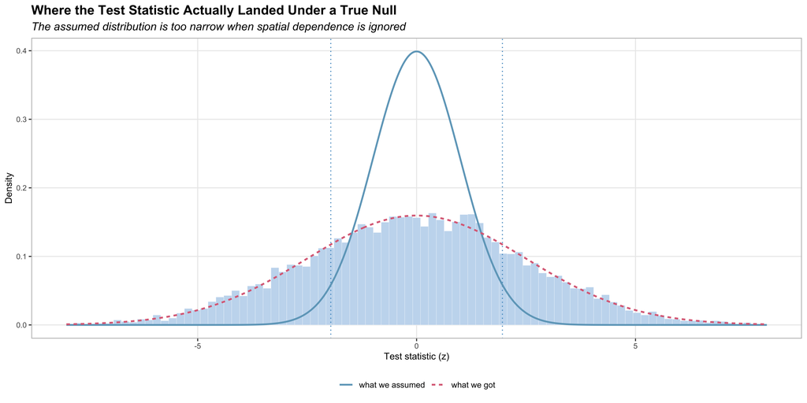

```r
dens <- tibble(z = seq(-8, 8, length.out = 600)) %>%
  mutate(
    `what we assumed` = dnorm(z),
    `what we got` = dnorm(z, sd = 1/sqrt(psi))) %>%
  pivot_longer(-z, names_to = "curve", values_to = "density") %>%
  mutate(curve = factor(curve,
                        levels = c("what we assumed", "what we got")))

ggplot() +
  geom_histogram(aes(z_naive, after_stat(density)), bins = 90,
                 fill = continuous_palette[2], colour = "white", linewidth = 0.1) +
  geom_vline(xintercept = c(-1.96, 1.96),
             colour = continuous_palette[4],
             linetype = "dotted", linewidth = 0.5) +
  geom_line(data = dens,
            aes(z, density, colour = curve, linetype = curve),
            linewidth = 0.9) +
  scale_colour_manual(values = cat2) +
  scale_x_continuous(limits = c(-8, 8)) +
  labs(
    title = "Where the Test Statistic Actually Landed Under a True Null",
    subtitle = "The assumed distribution is too narrow when spatial dependence is ignored",
    x = "Test statistic (z)",
    y = "Density") +
  themeGrid +
  theme(
    axis.title = element_text(size = 10),
    legend.position = "bottom",
    legend.title = element_blank())
```

Figure 4: Distribution of the naive test statistic across 10,000 simulations in which the null hypothesis is true.

The blue curve is the distribution the conventional test assumes. The pink curve represents the wider distribution produced when spatial dependence reduces the effective amount of information in the sample. The dotted lines at $\pm1.96$ were chosen because only 5% of a standard normal distribution lies beyond them. But once the actual distribution becomes wider, much more than 5% falls outside those same cutoffs.

The simulation makes this visible, but the resulting Type I error rate can also be calculated directly from $\psi$:

$$\alpha'
=
2\left[
1-\Phi(1.96\sqrt{\psi})
\right].$$

```r
tibble(
  source = c("predicted from psi alone", "10,000 simulations"),
  type_I = c(2 * (1 - pnorm(1.96 * sqrt(psi))), rejected)) %>%
  kable() %>%
  kable_styling(full_width = T)
```

| source | type_I |
| --- | --- |
| predicted from psi alone | 0.433 |
| 10,000 simulations | 0.435 |

The close agreement between the prediction and simulation confirms that the inflation comes from the information loss represented by $\psi$.

The previous example used $\rho=0.6$, but the same calculation can be repeated across different levels of spatial dependence.

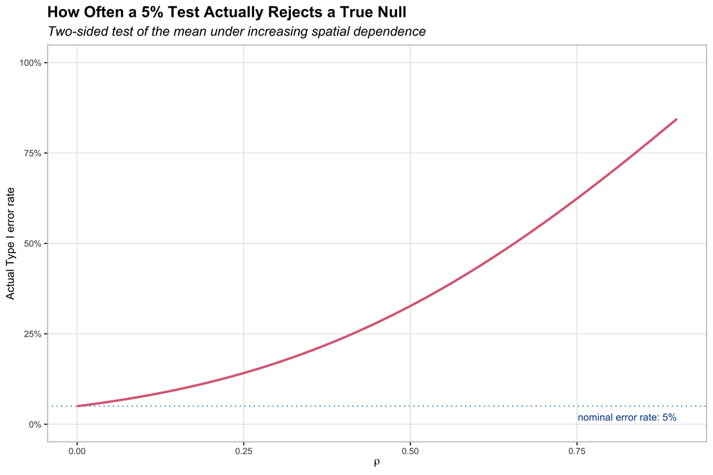

```r
tibble(rho = seq(0, 0.9, by = 0.005)) %>%
  mutate(err = 2 * (1 - pnorm(1.96 * sqrt((1 - rho)^2)))) %>%
  ggplot(aes(rho, err)) +
  geom_hline(yintercept = 0.05,
             colour = continuous_palette[4], linetype = "dotted") +
  geom_line(linewidth = 1, colour = cat2[2]) +
  annotate("text", x = 0.9, y = 0.02,
           label = "nominal error rate: 5%",
           hjust = 1, size = 3.2, colour = continuous_palette[5]) +
  scale_y_continuous(limits = c(0, 1),
                     labels = scales::label_percent()) +
  labs(
    title = "How Often a 5% Test Actually Rejects a True Null",
    subtitle = "Two-sided test of the mean under increasing spatial dependence",
    x = expression(rho),
    y = "Actual Type I error rate") +
  themeGrid +
  theme(axis.title = element_text(size = 10))
```

Figure 5: Actual Type I error rate produced by a nominal 5% test as spatial dependence increases.

At $\rho=0$, the procedure behaves exactly as promised. As dependence increases, the test becomes progressively more likely to reject a null hypothesis that is actually true. Even the relatively modest $\rho=0.3$ case from Figure 2 pushes the error rate to approximately **17%**. The visual appearance of spatial dependence and its statistical consequence therefore need not increase at the same rate.

## 4.3 Correcting the Z-Statistic

In this simplified example, the correction is conceptually straightforward. Instead of calculating the standard error from the nominal sample size $n$, we use the effective sample size $n'$:

```r
z_fixed <- xbar / (1 / sqrt(nprime))

tibble(
  test = c("using n = 25",
           "using n' = 4"),
  `rejection rate` = c(mean(abs(z_naive) > 1.96),
                       mean(abs(z_fixed) > 1.96))) %>%
  kable() %>%
  kable_styling(full_width = T)
```

| test | rejection rate |
| --- | --- |
| using n = 25 | 0.435 |
| using n’ = 4 | 0.050 |

Once the amount of information in the sample is represented correctly, the rejection rate returns close to the intended 5%. In real applications, the difficult part is usually not making this substitution. It is determining the spatial covariance structure — and therefore the effective amount of information — from the data. Those estimation problems, and their extensions to regression and other statistical models, come later in the course.

# 5. Statistical Testing in a Wheat Field

The previous examples were deliberately constructed so that we knew exactly how much dependence existed. We now finish with a real dataset.

Mercer and Hall’s 1911 study of wheat yields at Rothamsted, England is a classic early agricultural field experiment. A one-acre field was divided into a $20\times25$ grid, giving 500 individual cells with measured grain yield.

```r
if (!requireNamespace("agridat", quietly = TRUE)) {
  install.packages("agridat", repos = "https://cloud.r-project.org")
}

data(mercer.wheat.uniformity, package = "agridat")

wheat <- as_tibble(mercer.wheat.uniformity) %>%
  arrange(col, row)

tibble(
  quantity = c("cells", "mean grain yield", "standard deviation"),
  value = c(nrow(wheat), mean(wheat$grain), sd(wheat$grain))) %>%
  kable() %>%
  kable_styling(full_width = T)
```

| quantity | value |
| --- | --- |
| cells | 500.000 |
| mean grain yield | 3.949 |
| standard deviation | 0.458 |

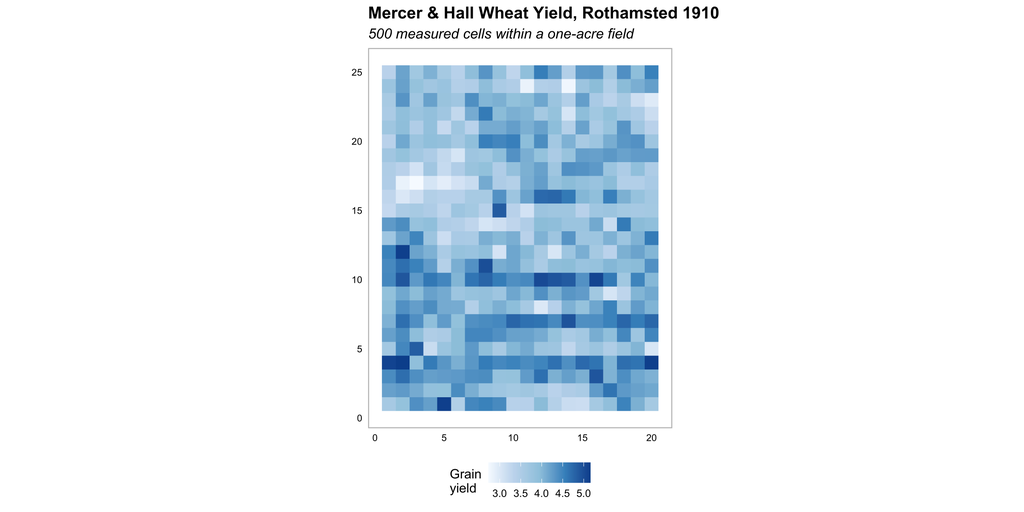

```r
ggplot(wheat, aes(row, col, fill = grain)) +
  geom_raster() +
  scale_fill_gradientn(colors = continuous_palette,
                       name = "Grain\nyield") +
  coord_fixed() +
  labs(
    title = "Mercer & Hall Wheat Yield, Rothamsted 1910",
    subtitle = "500 measured cells within a one-acre field") +
  themeClean +
  theme(
    axis.text = element_blank(),
    axis.ticks = element_blank(),
    legend.position = "bottom")
```

Figure 6: Grain yield across the 500 cells of the Rothamsted field experiment.

The pattern is visibly structured. Low-yielding cells form a band across one portion of the field, while higher-yielding cells cluster elsewhere. Neighboring cells frequently resemble one another, suggesting that the 500 observations do not contain 500 fully independent pieces of information.

We can estimate the strength of the dependence from the data. The details of this estimator are not important yet; for now, we use the resulting $\rho$ to calculate the same reduction factor introduced above.

```r
# APLE estimator (Li et al. 2007) -- see Problematic-Means.Rmd for the details
aple <- function(y, W) {
  n <- length(y)
  as.numeric(crossprod(y, ((t(W) + W)/2) %*% y)) /
    (as.numeric(crossprod(W %*% y)) +
       sum(diag(W %*% W)) * sum(y^2)/n)
}

Wwheat <- make_rook_W(20, 25)
rho_wheat <- aple(as.vector(scale(wheat$grain)), Wwheat)
psi_wheat <- (1 - rho_wheat)^2

tibble(
  quantity = c("estimated dependence (rho)",
               "reduction factor (psi)",
               "observations we have (n)",
               "observations we effectively have (n')"),
  value = c(rho_wheat, psi_wheat,
            nrow(wheat), nrow(wheat)*psi_wheat)) %>%
  kable() %>%
  kable_styling(full_width = T)
```

| quantity | value |
| --- | --- |
| estimated dependence (rho) | 0.574 |
| reduction factor (psi) | 0.181 |
| observations we have (n) | 500.000 |
| observations we effectively have (n’) | 90.690 |

The estimated spatial dependence is approximately $\rho=0.57$. Although the experiment contains 500 measured cells, the reduction factor implies that they contain approximately 90 independent observations worth of information. That is a substantial difference between how much data were collected and how much independent information those data contain.

The same discrepancy affects hypothesis tests. For a hypothetical one-sided test with a nominal Type I error rate of 5%, ignoring the spatial dependence would produce an actual error rate of approximately **24%**.

```r
tibble(
  quantity = c("actual error rate of a nominal 5% test (one-tailed)",
               "cutoff needed for a genuine 5% test (instead of 1.645)"),
  value = c(1 - pnorm(1.645 * sqrt(psi_wheat)),
            1.645 / sqrt(psi_wheat))) %>%
  kable() %>%
  kable_styling(full_width = T)
```

| quantity | value |
| --- | --- |
| actual error rate of a nominal 5% test (one-tailed) | 0.242 |
| cutoff needed for a genuine 5% test (instead of 1.645) | 3.863 |

The same issue appears in confidence intervals.

```r
xb <- mean(wheat$grain)
sw <- sd(wheat$grain)
np <- nrow(wheat) * psi_wheat

tibble(
  interval = c("naive (uses n = 500)",
               paste0("honest (uses n' = ", round(np), ")")),
  lower = xb - 1.96 * sw / sqrt(c(nrow(wheat), np)),
  upper = xb + 1.96 * sw / sqrt(c(nrow(wheat), np)),
  width = 2 * 1.96 * sw / sqrt(c(nrow(wheat), np))) %>%
  kable() %>%
  kable_styling(full_width = T)
```

| interval | lower | upper | width |
| --- | --- | --- | --- |
| naive (uses n = 500) | 3.91 | 3.99 | 0.080 |
| honest (uses n’ = 91) | 3.85 | 4.04 | 0.189 |

Accounting for spatial dependence makes the confidence interval approximately **2.35 times wider**.

# 6. Summary

This demonstration began with a simple idea: nearby geographic observations may contain partly overlapping information. When observations are spatially dependent, the number of measurements we collect is not necessarily the same as the amount of independent information those measurements provide. In the three-location example, two neighboring observations were strongly related, so treating all three observations as independent understated the uncertainty around the estimated mean and allowed the correlated pair to contribute more information than they actually contained.

We then used the **effective sample size** $n'$ and the **reduction factor** $\psi=n'/n$ to describe this loss of information. In the simulated lattice, increasing spatial dependence caused neighboring cells to become more similar and reduced the amount of independent information contained in the sample. Importantly, this loss can become substantial even when the spatial pattern does not look dramatically different. A sample may therefore appear large while behaving statistically like a much smaller collection of independent observations.

This loss of information has direct consequences for statistical inference. If a test assumes that all observations are independent, its standard error can be too small, confidence intervals can be too narrow, and a true null hypothesis can be rejected much more often than the nominal significance level suggests. In the simulation, the null hypothesis was true in every run, but ignoring spatial dependence caused the conventional z-test to reject it far more often than the expected 5%. Once the effective amount of information in the sample was accounted for, the test behaved much closer to its intended error rate.

The Rothamsted wheat data show that this is not only a theoretical problem. Although the field contains 500 measured cells, spatial dependence means that those observations contain considerably fewer independent observations worth of information. The broader lesson is that **collecting many observations is not the same thing as collecting many independent pieces of information**. For geographic data, understanding how observations are related in space is therefore an important part of understanding the uncertainty, precision, and reliability of the statistical conclusions we draw from them.

# Sources

Mercer, W. B., & Hall, A. D. (1911). The experimental error of field trials. *Journal of Agricultural Science*, 4, 107–132.

Rogerson, P. A. (2021). *Spatial Statistical Methods for Geography*, Ch. 1.3.4 and Ch. 8. SAGE.